# DAT205x: Introduction to Data Analysis using R. Lab1

# Scenario

You are the new marketing manager of an established Bicycle company. The company sells bicycles and accessories, such as clothing and other accessories to bikers in six countries. The company has just hired Lucy as its new Sales manager. You are tasked to introduce Lucy to the company, its product portfolio and its sales performance since 2011. To do this, you have asked Jack, the IT manager to prepare some data for you. Now, it’s your job to present this data in a compelling manner.

Load necessary libraries

```r
library(tidyverse)
library(readxl)
library(DT)
```

```r
my_data <- read_excel("./week1/raw_data.xlsx")
```

Let’s view how our raw data looks like:

```r
str(my_data)
```

```
Classes ‘tbl_df’, ‘tbl’ and 'data.frame':   113036 obs. of  15 variables:
 $ Date            : POSIXct, format: "2013-11-26" "2015-11-26" "2014-03-23" "2016-03-23" ...
 $ Year            : num  2013 2015 2014 2016 2014 ...
 $ Customer ID     : num  11019 11019 11039 11039 11046 ...
 $ Customer Age    : num  19 19 49 49 47 47 47 47 35 35 ...
 $ Customer Gender : chr  "M" "M" "M" "M" ...
 $ Country         : chr  "Canada" "Canada" "Australia" "Australia" ...
 $ State           : chr  "British Columbia" "British Columbia" "New South Wales" "New South Wales" ...
 $ Product Category: chr  "Accessories" "Accessories" "Accessories" "Accessories" ...
 $ Sub Category    : chr  "Bike Racks" "Bike Racks" "Bike Racks" "Bike Racks" ...
 $ Product         : chr  "Hitch Rack - 4-Bike" "Hitch Rack - 4-Bike" "Hitch Rack - 4-Bike" "Hitch Rack - 4-Bike" ...
 $ Order Quantity  : num  8 8 23 20 4 5 4 2 22 21 ...
 $ Unit Cost       : num  45 45 45 45 45 45 45 45 45 45 ...
 $ Unit Price      : num  120 120 120 120 120 120 120 120 120 120 ...
 $ Cost            : num  360 360 1035 900 180 ...
 $ Revenue         : num  950 950 2401 2088 418 ...
```

```r
datatable(my_data[1:100, ],
          class = "cell-border stripe nowrap",
          options = list(scrollX = T, dom = 'tp', autoWidth = TRUE,
                         columnDefs = list(list(className = 'dt-body-center', targets = "_all")))) %>%
    formatDate(1, method = "toDateString")
```

|  | Date | Year | Customer ID | Customer Age | Customer Gender | Country | State | Product Category | Sub Category | Product | Order Quantity | Unit Cost | Unit Price | Cost | Revenue |
| --- | --- | --- | --- | --- | --- | --- | --- | --- | --- | --- | --- | --- | --- | --- | --- |
| 1 | 2013-11-26T00:00:00Z | 2013 | 11019 | 19 | M | Canada | British Columbia | Accessories | Bike Racks | Hitch Rack - 4-Bike | 8 | 45 | 120 | 360 | 950 |
| 2 | 2015-11-26T00:00:00Z | 2015 | 11019 | 19 | M | Canada | British Columbia | Accessories | Bike Racks | Hitch Rack - 4-Bike | 8 | 45 | 120 | 360 | 950 |
| 3 | 2014-03-23T00:00:00Z | 2014 | 11039 | 49 | M | Australia | New South Wales | Accessories | Bike Racks | Hitch Rack - 4-Bike | 23 | 45 | 120 | 1035 | 2401 |
| 4 | 2016-03-23T00:00:00Z | 2016 | 11039 | 49 | M | Australia | New South Wales | Accessories | Bike Racks | Hitch Rack - 4-Bike | 20 | 45 | 120 | 900 | 2088 |
| 5 | 2014-05-15T00:00:00Z | 2014 | 11046 | 47 | F | Australia | New South Wales | Accessories | Bike Racks | Hitch Rack - 4-Bike | 4 | 45 | 120 | 180 | 418 |
| 6 | 2016-05-15T00:00:00Z | 2016 | 11046 | 47 | F | Australia | New South Wales | Accessories | Bike Racks | Hitch Rack - 4-Bike | 5 | 45 | 120 | 225 | 522 |
| 7 | 2014-05-22T00:00:00Z | 2014 | 11047 | 47 | F | Australia | Victoria | Accessories | Bike Racks | Hitch Rack - 4-Bike | 4 | 45 | 120 | 180 | 379 |
| 8 | 2016-05-22T00:00:00Z | 2016 | 11047 | 47 | F | Australia | Victoria | Accessories | Bike Racks | Hitch Rack - 4-Bike | 2 | 45 | 120 | 90 | 190 |
| 9 | 2014-02-22T00:00:00Z | 2014 | 11094 | 35 | M | Australia | Victoria | Accessories | Bike Racks | Hitch Rack - 4-Bike | 22 | 45 | 120 | 990 | 2086 |
| 10 | 2016-02-22T00:00:00Z | 2016 | 11094 | 35 | M | Australia | Victoria | Accessories | Bike Racks | Hitch Rack - 4-Bike | 21 | 45 | 120 | 945 | 1991 |

[output cut: 90 more lines]

The first thing you’d like to do is to present the data graphically. You do this by creating charts for the three groups of data you received from Jack, your IT manager. If you haven’t done so, give the chart a descriptive title.

Your first solution should look like this (numbers may not be the same).

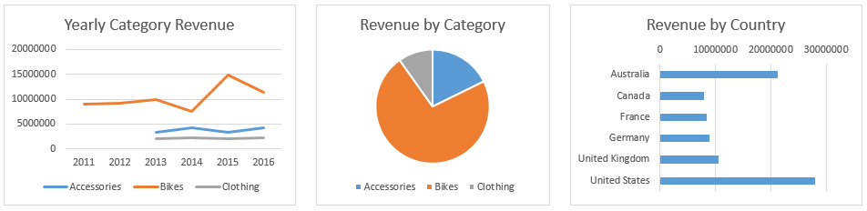

Create three type of chart as showed above and answer the next questions.

#### **Question 1:** What does the Yearly total sales look like?

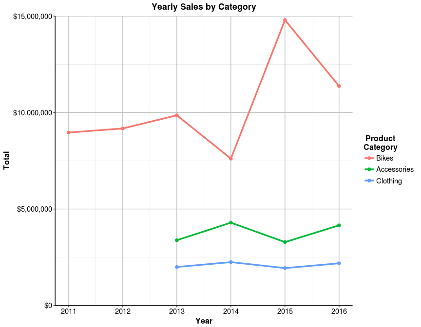

#### **Answer:** Similar to the yearly bikes revenue

#### **Question 2:** What percentage of the total revenue comes from the Bikes category?

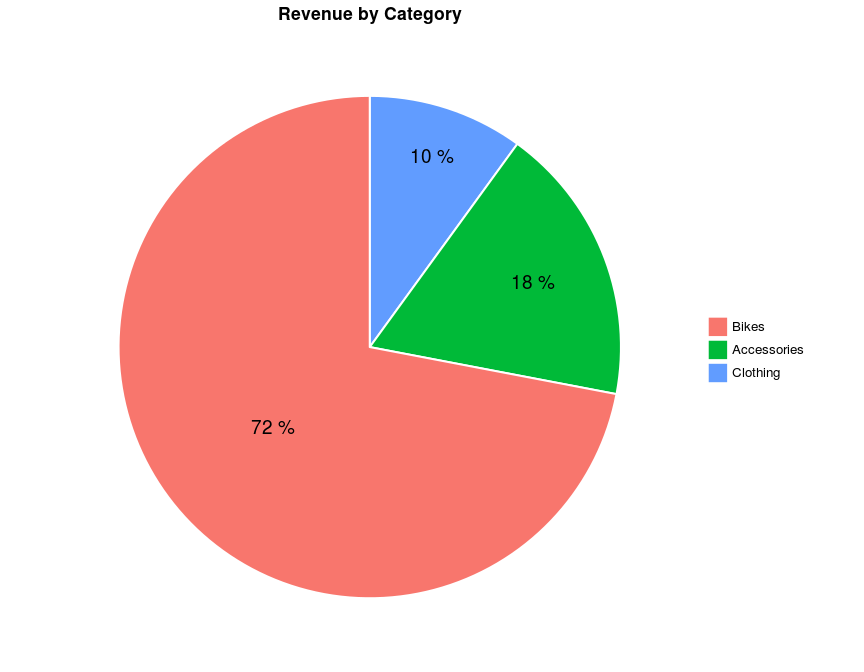

```r
my_data %>%
    group_by(`Product Category`) %>%
    summarise(Total = sum(Revenue)) %>%
    arrange(desc(Total)) %>%
    mutate(Prop = formatC(Total / sum(Total), digits = 2, format = "f") %>%
               as.numeric(),
           Percent = paste(Prop * 100, "%"),
           y_tick = cumsum(Prop) - Prop / 2) %>%
    ggplot(aes(x = "", y = Prop, fill = reorder(`Product Category`, -Prop))) +
    geom_bar(width = 1, stat = "identity", colour = "white", size = 0.7) +
    coord_polar(theta = "y") +
    labs(title = "Revenue by Category", x = NULL, y = NULL) +
    geom_text(aes(x = c(1.0, 1.2, 1.3), y = 1 - y_tick, label = Percent), size = 5) +
    theme(panel.background = element_rect(fill = "white", color = "white"),
          plot.title = element_text(face = "bold", hjust = 0.5),
          legend.title = element_blank(),
          legend.text = element_text(size = 10, color = "black"),
          axis.text = element_blank(),
          axis.ticks = element_blank(),
          axis.line = element_blank())
```

#### **Answer:** 72%

#### **Question 3:** For the Revenue by Country, sort the countries from the one with highest revenue to lowest revenue.

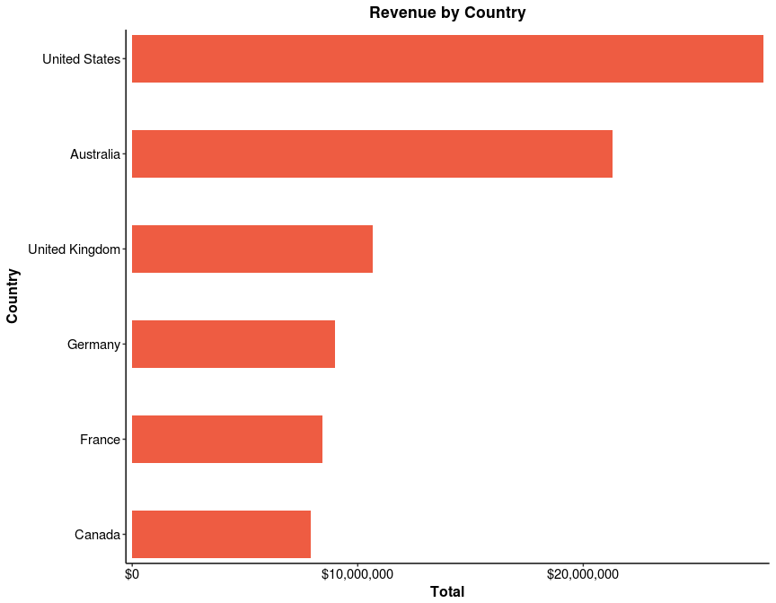

Save data for next lab:

```r
saveRDS(my_data, "week1/data4week2.rds")
```